# R Notebook

Adapted by sjgknight from chapter in Lisa DeBruine & Dale Barr. (2021). Data Skills for Reproducible Research Zenodo. doi:10.5281/zenodo.3564348 `citation('reprores')`

2022-02-04

## Learning Objectives

### Basic

1. Understand what types of graphs are best for different types of data [(video)](https://youtu.be/tOFQFPRgZ3M)
   - 1 discrete
   - 1 continuous
   - 2 discrete
   - 2 continuous
   - 1 discrete, 1 continuous
   - 3 continuous
2. Create common types of graphs with ggplot2 [(video)](https://youtu.be/kKlQupjD__g)
   - `geom_bar()`
   - `geom_density()`
   - `geom_freqpoly()`
   - `geom_histogram()`
   - `geom_col()`
   - `geom_boxplot()`
   - `geom_violin()`
   - Vertical Intervals
     - `geom_crossbar()`
     - `geom_errorbar()`
     - `geom_linerange()`
     - `geom_pointrange()`
   - `geom_point()`
   - `geom_smooth()`
3. Set custom size, labels, colours, and themes [(video)](https://youtu.be/6pHuCbOh86s)
4. Combine plots on the same plot, as facets, or as a grid using patchwork [(video)](https://youtu.be/AnqlfuU-VZk)
5. Save plots as an image file [(video)](https://youtu.be/f1Y53mjEli0)

### Intermediate

6. Add lines to graphs
7. Deal with overlapping data
8. Create less common types of graphs
   - `geom_tile()`
   - `geom_density2d()`
   - `geom_bin2d()`
   - `geom_hex()`
   - `geom_count()`
9. Adjust axes (e.g., flip coordinates, set axis limits)

## Setup

```r
# libraries needed for these graphs
library(tidyverse)
library(patchwork)
library(reprores)
library(glossary)
set.seed(30250) # makes sure random numbers are reproducible
knitr::opts_chunk$set(eval = TRUE)
```

## Common Variable Combinations

[Continuous](https://psyteachr.github.io/glossary/c#continuous) variables are properties you can measure, like height. [Discrete](https://psyteachr.github.io/glossary/d#discrete) variables are things you can count, like the number of pets you have. Categorical variables can be nominal, where the categories don’t really have an order, like cats, dogs and ferrets (even though ferrets are obviously best). They can also be ordinal, where there is a clear order, but the distance between the categories isn’t something you could exactly equate, like points on a [Likert](https://psyteachr.github.io/glossary/l#likert) rating scale.

Different types of visualisations are good for different types of variables.

Load the `pets` dataset and explore it with `glimpse(pets)` or `View(pets)`. This is a simulated dataset with one random factor (`id`), two categorical factors (`pet`, `country`) and three continuous variables (`score`, `age`, `weight`).

```r
#data("pets", package = "reprores")
# if you don't have the reprores package, use:
pets <- read_csv("https://psyteachr.github.io/reprores/data/pets.csv", col_types = "cffiid")
glimpse(pets)
```

```
## Rows: 800
## Columns: 6
## $ id      <chr> "S001", "S002", "S003", "S004", "S005", "S006", "S007", "S008"~
## $ pet     <fct> dog, dog, dog, dog, dog, dog, dog, dog, dog, dog, dog, dog, do~
## $ country <fct> UK, UK, UK, UK, UK, UK, UK, UK, UK, UK, UK, UK, UK, UK, UK, UK~
## $ score   <int> 90, 107, 94, 120, 111, 110, 100, 107, 106, 109, 85, 110, 102, ~
## $ age     <int> 6, 8, 2, 10, 4, 8, 9, 8, 6, 11, 5, 9, 1, 10, 7, 8, 1, 8, 5, 13~
## $ weight  <dbl> 19.78932, 20.01422, 19.14863, 19.56953, 21.39259, 21.31880, 19~
```

Before you read ahead, come up with an example of each type of variable combination and sketch the types of graphs that would best display these data.

- 1 categorical
- 1 continuous
- 2 categorical
- 2 continuous
- 1 categorical, 1 continuous
- 3 continuous

## Basic Plots

R has some basic plotting functions, but they’re difficult to use and aesthetically not very nice. They can be useful to have a quick look at data while you’re working on a script, though. The function `plot()` usually defaults to a sensible type of plot, depending on whether the arguments `x` and `y` are categorical, continuous, or missing.

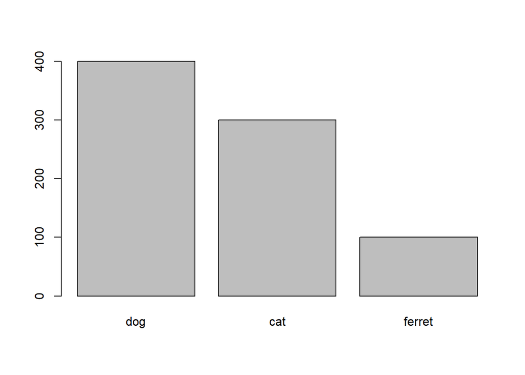

plot() with categorical x

```r
plot(x = pets$pet)
```

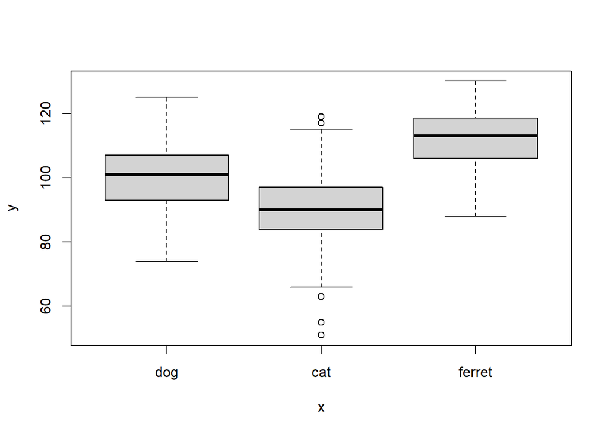

plot() with categorical x and continuous y

```r
plot(x = pets$pet, y = pets$score)
```

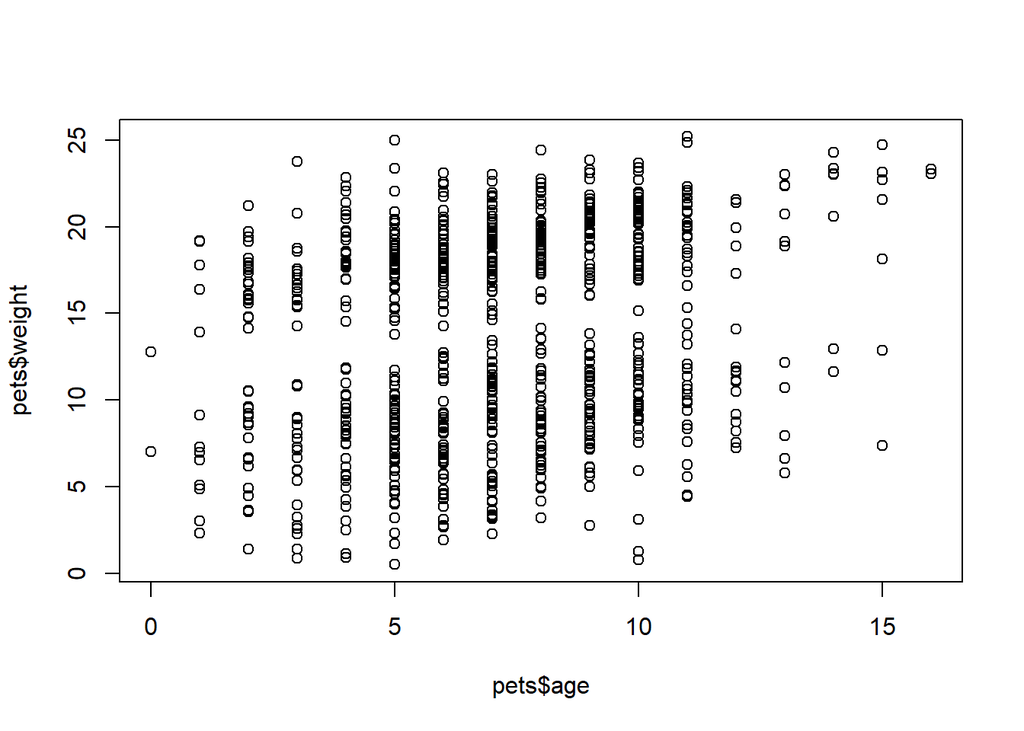

plot() with continuous x and y

```r
plot(x = pets$age, y = pets$weight)
```

The function `hist()` creates a quick histogram so you can see the distribution of your data. You can adjust how many columns are plotted with the argument `breaks`.

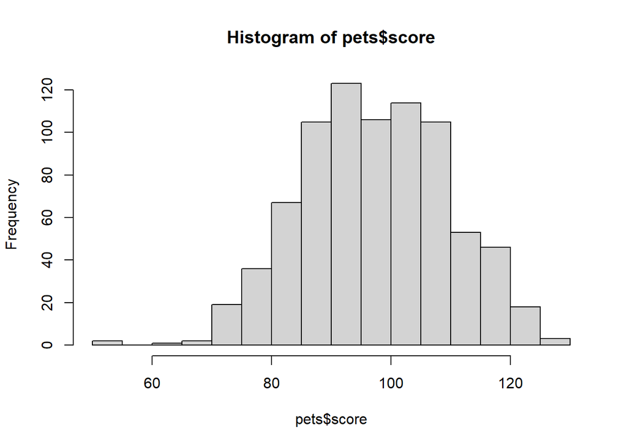

hist()

```r
hist(pets$score, breaks = 20)
```